# Integrated DRIFTS Analysis

Adrianne Seiden

2026-07-08

# Overview

This document imports and analyzes FTIR DRIFTS data from DPT files, normalizes & plots the spectra, calculates functional group proportions, and visualizes the results. It knits to an HTML document, saved in my GitHub repository. The general analysis pipeline is based on methods from Mainka et al. (2022), with modifications to fit the Salk project variables (crop type and decomposition time). Mainka, M., Summerauer, L., Wasner, D., Garland, G., Griepentrog, M., Berhe, A. A., & Doetterl, S. (2022). Soil geochemistry as a driver of soil organic matter composition: Insights from a soil chronosequence. Biogeosciences, 19(6), 1675–1689. https://doi.org/10.5194/bg-19-1675-2022

## Statistical Methods

### 2. **Spectral Integration for Functional Groups**

Functional group proportions are calculated using integrated peak areas from specific spectral regions (based on Mainka et al. 2022): - Peak areas are calculated using the **trapezoidal rule** (via the `pracma::trapz()` function) across four spectral windows: - **Simple plant (aliphatic)**: 2839–2870 cm⁻¹ + 2898–2976 cm⁻¹ - **Complex plant (aromatic)**: 1500–1550 cm⁻¹ - **Microbial**: 1580–1660 cm⁻¹

- **Proportion calculation**: Each functional group’s proportion is calculated as:
  $$\text{Proportion} = \frac{\text{Peak
  Area}_{\text{functional group}}}{\text{Total Peak Area}_{\text{all
  groups}}}$$
- **Ratio metrics** are derived from these proportions (e.g., Simple:Complex-plant ratio, Total Plant:Microbial ratio)

### 3. **Descriptive Statistics by Group**

Summary statistics are calculated by crop and timepoint: - **Mean** and **Standard Error (SE)** for each functional group proportion
$$SE =
\frac{SD}{\sqrt{n}}$$
where SD is the standard deviation and n is the sample size for each group

### 4. **Linear Regression Analysis (Ratio Scatterplots)**

Time-series trends are analyzed using **simple linear regression** for each crop, fitting all individual data points (not just group averages): - **Model**: `y ~ timepoint_numeric` where y is a ratio metric (e.g., Simple:Microbial) - **Statistics reported**: - **R²** (coefficient of determination): Explains the proportion of variance in the ratio accounted for by timepoint - **Slope**: The change in ratio per week, fitted to all individual replicate measurements - **P-value**: Statistical significance test (α = 0.05); values < 0.05 marked with asterisk

This approach uses all available replicate data for regression rather than averaged values, providing more robust statistical inference.

### 5. **Data Visualization**

- **Ridge plots**: Use transparent ribbons to show the full range of spectral data (min to max across samples from the same crop and timepoint), with overlaid opaque lines showing the mean intensity. Annotations indicate the spectral regions used for functional group integration.
- **Stacked bar plots**: Display functional group proportions by crop over time, with labels indicating the proportion represented by each functional group as a percentage of the total integrated area.
- **Ratio scatterplots**: Display averaged ratios with error bars, overlaid with fitted regression lines and statistics (based on all individual data points).

### 6. **Data Aggregation Levels**

- Timepoint-level summaries (across all crops)
- Crop-level summaries (across all timepoints)
- Crop × Timepoint summaries (group means and SEs)

All statistical calculations are implemented in R using `dplyr` for data manipulation, `ggplot2` for visualization, and base R functions for statistical modeling.

# Setting up

This section sets up the environment, loads required libraries, and defines paths to data and output directories. It also includes a helper function to find the most recent processed integration data file, so that the code does not need to re-analyze dpt files that have already been processed every time it is run.

# Preparing data for analysis

## Importing DPT data

```r
# Check if folder exists and list files
if (!dir.exists(dpt_folder)) {
  stop("Directory does not exist: ", dpt_folder)
}

# List and sort files
cat("Files found in directory:\n")
```

```
## Files found in directory:
```

```r
print(list.files(dpt_folder))
```

```
##  [1] "DRIFTS_Pot001_13Cwheat_wk0_rhizoSoil_260618.0.dpt"
##  [2] "DRIFTS_Pot012_13Csoy_wk10_rhizoSoil_260624.0.dpt"
##  [3] "DRIFTS_Pot020_12CnoPlant_wk30_rhizoSoil_260617.0.dpt"
##  [4] "DRIFTS_Pot020_12CnoPlant_wk40_rhizoSoil_260617.0.dpt"
##  [5] "DRIFTS_Pot024_13Cwheat_wk0_rhizoSoil_260618.0.dpt"
##  [6] "DRIFTS_Pot028_13Cwheat_wk0_rhizoSoil_260618A.0.dpt"
##  [7] "DRIFTS_Pot028_13Cwheat_wk0_rhizoSoil_260618B.0.dpt"
##  [8] "DRIFTS_Pot029_13Cwheat_wk10_rhizoSoil_260624.0.dpt"
##  [9] "DRIFTS_Pot029_13Cwheat_wk40_rhizoSoil_260702.0.dpt"
## [10] "DRIFTS_Pot030_13Csoy_wk40_rhizoSoil_260702.0.dpt"
## [11] "DRIFTS_Pot032_13Cwheat_wk0_rhizoSoil_260618.0.dpt"
## [12] "DRIFTS_Pot044_13CnoPlant_wk0_bulkSoil_260617.0.dpt"
## [13] "DRIFTS_Pot044_13CnoPlant_wk10_rhizoSoil_260617.0.dpt"
## [14] "DRIFTS_Pot044_13CnoPlant_wk40_rhizoSoil_260617.0.dpt"
## [15] "DRIFTS_Pot050_13Csoy_wk0_rhizoSoil_260618.0.dpt"
```

[output cut: 34 more lines]

```r
DPTfiles <- sort(list.files(dpt_folder, pattern = ".dpt"))
cat("Number of .dpt files:", length(DPTfiles), "\n")
```

```
## Number of .dpt files: 49
```

```r
# Read files individually and combine
dpt_data_list <- list()

for (i in seq_along(DPTfiles)) {
  file_path <- file.path(dpt_folder, DPTfiles[i])

  # Read as lines and parse manually (DPT files are space-delimited)
  lines <- readLines(file_path, warn = FALSE)
  lines <- lines[lines != ""]  # Remove empty lines

  # Split each line by whitespace
  split_lines <- strsplit(lines, "\\s+")

  # Convert to data frame
  temp_data <- tryCatch({
    data.frame(
      wavenumber = as.numeric(sapply(split_lines, `[`, 1)),
      absorbance = as.numeric(sapply(split_lines, `[`, 2)),
      stringsAsFactors = FALSE
    )
  }, error = function(e) NULL)

  if (!is.null(temp_data)) {
    # Add filename column
    temp_data$filename <- DPTfiles[i]

    # Store in list
    dpt_data_list[[i]] <- temp_data
  }
}

# Remove NULL entries (failed reads)
dpt_data_list <- dpt_data_list[!sapply(dpt_data_list, is.null)]

# Combine all data
dpt_data <- bind_rows(dpt_data_list)

# Remove any rows with NA values
dpt_data <- dpt_data[complete.cases(dpt_data), ]

# Extract metadata from filenames
dpt_data <- dpt_data %>%
  mutate(
    crop = case_when(
      str_detect(filename, "noPlant") ~ "noPlant",
      str_detect(filename, "wheat") ~ "wheat",
      str_detect(filename, "rice") ~ "rice",
      str_detect(filename, "soy") ~ "soy",
      TRUE ~ NA_character_
    ),
    timepoint = str_extract(filename, "wk\\d+"),
    sample_type = case_when(
      str_detect(filename, "root") ~ "root",
      str_detect(filename, "rhizoSoil") ~ "rhizoSoil",
      str_detect(filename, "bulkSoil") ~ "bulkSoil",
      TRUE ~ NA_character_
    ),
    # Extract ID (pot number) from filename
ID = case_when(
      str_detect(filename, regex("pot[0-9]+", ignore_case = TRUE)) ~
        str_extract(filename, regex("pot[0-9]+", ignore_case = TRUE)) %>%
        str_remove(regex("pot", ignore_case = TRUE)) %>%
        str_pad(width = 3, pad = "0"),
      # Alternative pattern for files without 'pot' prefix
      str_detect(filename, regex("DRIFTS_[0-9]+", ignore_case = TRUE)) ~ str_extract(filename, regex("DRIFTS_[0-9]+", ignore_case = TRUE)) %>%
                                              str_remove(regex("DRIFTS_", ignore_case = TRUE)) %>%
                                              str_pad(width = 3, pad = "0"),
      TRUE ~ NA_character_
    )
  ) %>%
  filter(!is.na(sample_type)) %>%  # Remove files without clear sample type
  filter(!str_detect(filename, "KBr")) %>%  # Remove KBr files if needed
  # Filter out anomalous spectra if needed
  filter(!filename %in% c("DRIFTS_Pot109_13Cwheat_wk10_rhizoSoil_260624a.0.dpt",
                          "DRIFTS_pot047_13Crice_wk0_root_250725.0.dpt")) # examples of bad spectra
# save as csv for record-keeping
write.csv(dpt_data, file.path(outputs_folder, "dpt_data.csv"), row.names = FALSE)
```

## Normalizing data

This code is modified to use baseline correction (subtracting the minimum) and standard normal variate (SNV) normalization.

```r
# Normalize absorbance data by sample (same approach as OPUSprocessing.Rmd)
dpt_data <- dpt_data %>%
  group_by(filename) %>%
  mutate(
    # Baseline correction - subtract minimum
    baseline_corrected = absorbance - min(absorbance, na.rm = TRUE),
    # Apply SNV (Standard Normal Variate) normalization
    mean_abs = mean(baseline_corrected, na.rm = TRUE),
    sd_abs = sd(baseline_corrected, na.rm = TRUE),
    normalized_absorbance = (baseline_corrected - mean_abs) / sd_abs
  ) %>%
  select(-mean_abs, -sd_abs) %>%
  ungroup()
dpt_data <- dpt_data %>%
  group_by(filename) %>%
  mutate(
    # Baseline correction - subtract minimum
    snv_corrected = normalized_absorbance - min(normalized_absorbance, na.rm = TRUE)
  ) %>%
  ungroup()

dpt_data <- dpt_data %>%
  group_by(filename) %>%
  mutate(
    # Baseline correction + 1
    snv_plusOne = normalized_absorbance + 1
  ) %>%
  ungroup()

## Save normalized data for record-keeping

write.csv(dpt_data, file.path(outputs_folder, "dpt_data_normalized.csv"), row.names = FALSE)
```

# Plotting DRIFTS spectra

## Plotting by timepoint

### Ridge plots

These plots are of normalized absorbance values. The thickness of the opaque line represents the range of the data. Annotations indicate integration regions used for calculations of simple plant, complex plant, and microbial organic matter proportions. Integration regions according to Mainka et al. (2022):

Mainka, M., Summerauer, L., Wasner, D., Garland, G., Griepentrog, M., Berhe, A. A., & Doetterl, S. (2022). Soil geochemistry as a driver of soil organic matter composition: Insights from a soil chronosequence. Biogeosciences, 19(6), 1675–1689. https://doi.org/10.5194/bg-19-1675-2022

| Simple plant (aliphatic): | 2976 - 2898 cm<sup>-1</sup> + 2870 - 2839 cm<sup>-1</sup> |
| --- | --- |
| Microbial: | 1660 - 1580 cm<sup>-1</sup> |
| Complex plant (aromatic): | 1550 - 1500 cm<sup>-1</sup> |

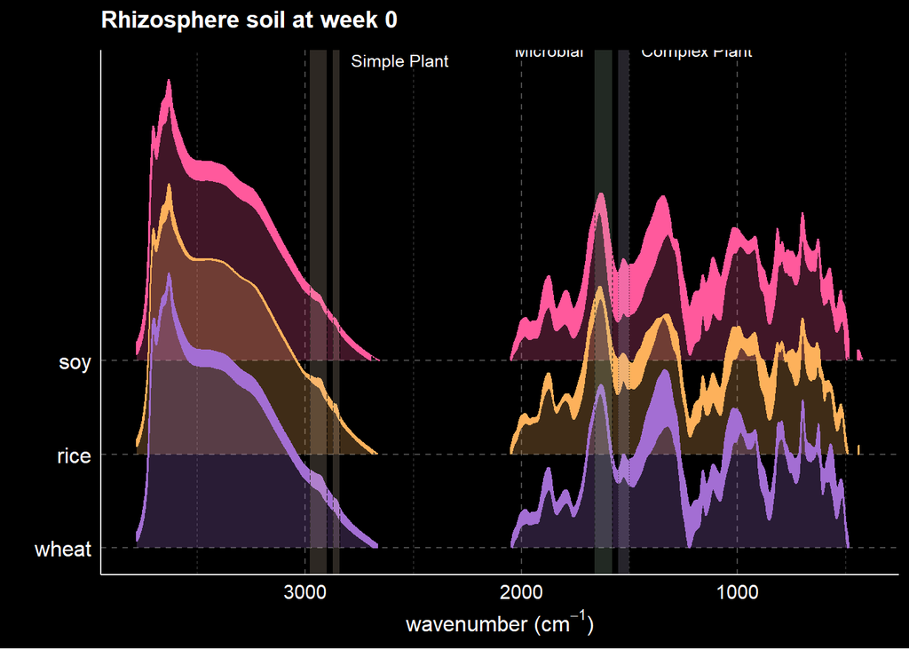

| Week 0 samples |
| --- |
| 5 wheat |
| 3 rice |
| 3 soy |

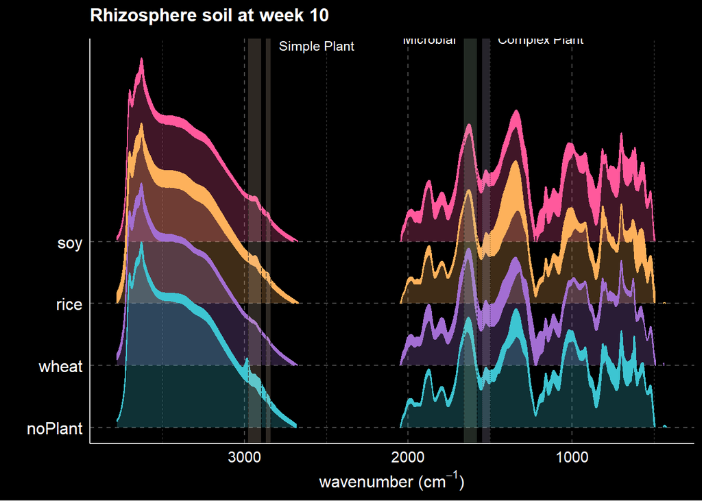

| Week 10 samples |
| --- |
| 4 noPlant |
| 3 wheat |
| 5 rice |
| 4 soy |

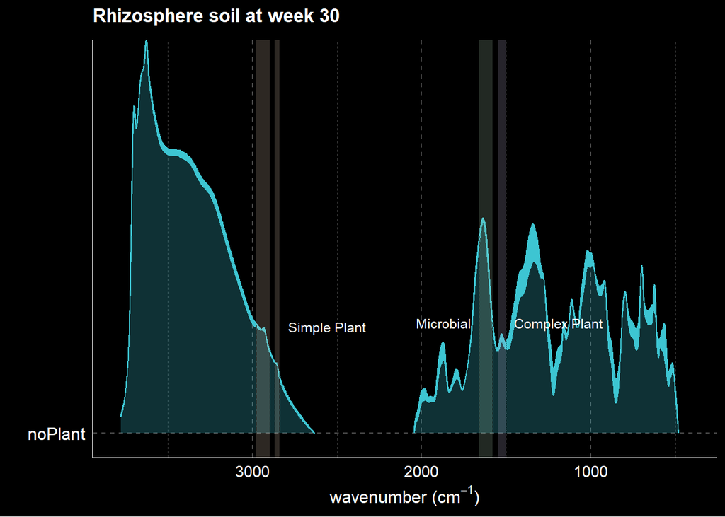

| Week 30 samples |
| --- |
| 2 noPlant |

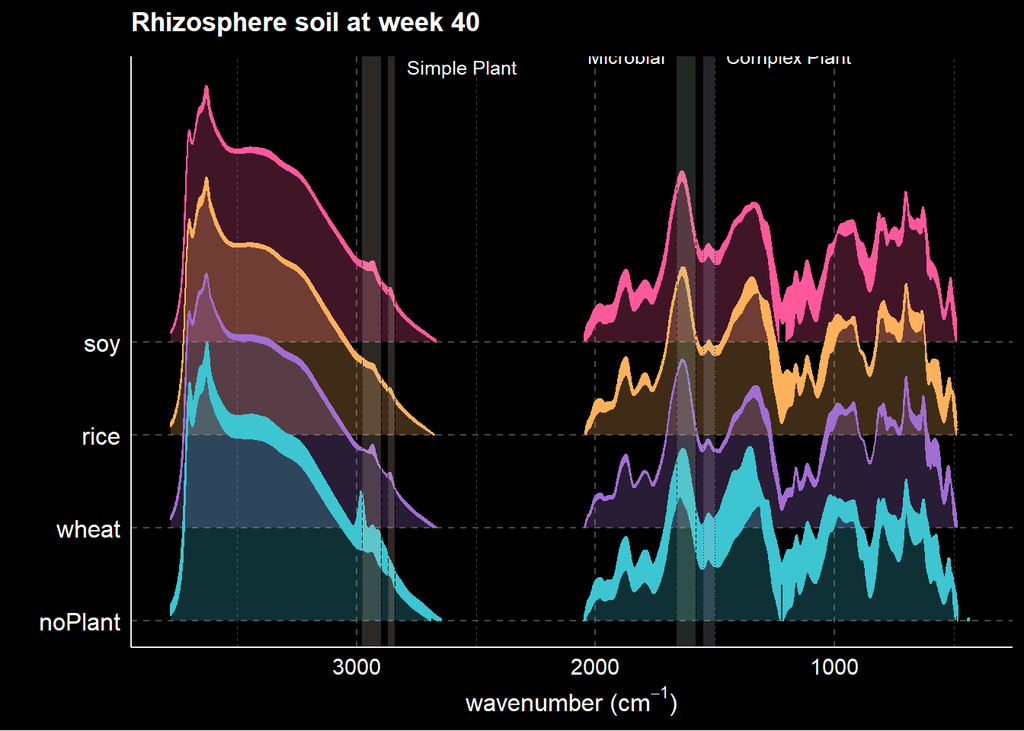

| Week 40 samples |
| --- |
| 7 noPlant |
| 3 wheat |
| 3 rice |
| 3 soy |

```r
# Filter for rhizoSoil samples only
dpt_data_rhizo <- dpt_data %>%
  filter(sample_type == "rhizoSoil") %>%
  filter(!is.na(crop))

# Generic function to create ridge plots for any timepoint
create_timepoint_ridge_plot <- function(data, timepoint_week, title = NULL) {
  # Filter data for specific timepoint
  filtered_data <- data %>%
    filter(timepoint == timepoint_week) %>%
    mutate(crop = factor(crop, levels = c("noPlant", "wheat", "rice", "soy")))

  # Create title if not provided
  if (is.null(title)) {
    week_num <- str_extract(timepoint_week, "\\d+")
    title <- paste("Rhizosphere soil at week", week_num)
  }

  # Determine y-position for annotations based on data
  present_levels <- levels(droplevels(filtered_data$crop))  # only levels actually in this week's data, in original order
  peak_heights <- filtered_data %>%
    group_by(crop) %>%
    summarise(group_max = max(snv_plusOne, na.rm = TRUE)) %>%
    mutate(baseline = match(as.character(crop), present_levels))  # true rendered position, not raw factor code
  global_max <- max(peak_heights$group_max, na.rm = TRUE)
  max_y <- max(peak_heights$baseline + 3 * (peak_heights$group_max / global_max)) + 0.2
#   n_groups <- length(unique(filtered_data$crop))
#   ridge_scale <- 3  # matches your geom_density_ridges(scale = 3)
#   max_y <- n_groups + ridge_scale * .33 + 0.33  # headroom above the top category



  # Create the plot
  ridge_plot <- filtered_data %>%
    ggplot(mapping = aes(x = wavenumber,
                         y = crop,
                         height = snv_plusOne,
                         group = crop,
                         fill = crop,
                         color = crop)) +
    geom_density_ridges(stat = "identity",
                        scale = 3, # overlap scale - 1 is no overlap, >1 is more overlap
                        alpha = 0.25) +
    geom_vline(xintercept = 1500, linetype = "dotted", linewidth = 0.23) +
    geom_vline(xintercept = 1550, linetype = "dotted", linewidth = 0.23) +
    geom_vline(xintercept = 1580, linetype = "dashed", linewidth = 0.23) +
    geom_vline(xintercept = 1660, linetype = "dashed", linewidth = 0.23) +
    geom_vline(xintercept = 2839, linetype = "longdash", linewidth = 0.23) +
    geom_vline(xintercept = 2870, linetype = "longdash", linewidth = 0.23) +
    geom_vline(xintercept = 2898, linetype = "longdash", linewidth = 0.23) +
    geom_vline(xintercept = 2976, linetype = "longdash", linewidth = 0.23) +
    xlim(3777, 422) +
    scale_y_discrete(expand = expansion(mult = c(0, 0.1), add = c(0, 0))) +  # space below, space above+  # space below, space above

    theme(axis.text.y = element_text(size = 12),
          legend.position = "none") +
    scale_fill_manual(values = crop_colors) +
    scale_color_manual(values = crop_colors) +
    ggtitle(title) +
    labs(x = expression("wavenumber (cm"^-1*")"), y = "") +
    # Add simple plant region annotation
    annotate("rect", xmin = 2976, xmax = 2898, ymin = -Inf, ymax = Inf,
             alpha = 0.2, fill = "#e3c8b1") +
    annotate("rect", xmin = 2870, xmax = 2839, ymin = -Inf, ymax = Inf,
             alpha = 0.2, fill = "#e3c8b1") +
    annotate("text", x = 2560, y = max_y, label = "Simple Plant",
             size = 3.3, hjust = 0.5, color = annotation_text_color) +
    # Add microbial region annotation
    annotate("rect", xmin = 1660, xmax = 1580, ymin = -Inf, ymax = Inf,
             alpha = 0.2, fill = "#a8cbad") +
    annotate("text", x = 1870, y = max_y + 0.11, label = "Microbial",
             size = 3.3, hjust = 0.5, color = annotation_text_color) +
    # Add complex plant region annotation
    annotate("rect", xmin = 1550, xmax = 1500, ymin = -Inf, ymax = Inf,
             alpha = 0.2, fill = "#beb5d5") +
    annotate("text", x = 1190, y = max_y + 0.11, label = "Complex Plant",
             size = 3.3, hjust = 0.5, color = annotation_text_color)

  return(list(plot = ridge_plot, data = filtered_data))
}

# Generic function to create sample count tables
create_sample_count_table <- function(filtered_data, timepoint_week) {
  week_num <- str_extract(timepoint_week, "\\d+")
  col_name <- paste("Week", week_num, "samples")

  counts <- filtered_data %>%
    select(filename, crop) %>%
    distinct() %>%
    count(crop) %>%
    arrange(match(crop, c("noPlant", "wheat", "rice", "soy"))) %>%
    mutate(!!col_name := paste(n, "&nbsp;&nbsp;", crop)) %>%
    select(all_of(col_name))

  return(counts)
}

# Create plots and tables for each timepoint
timepoints <- sort(unique(dpt_data_rhizo$timepoint))

for (tp in timepoints) {
  # Create plot and get filtered data
  result <- create_timepoint_ridge_plot(dpt_data_rhizo, tp)

  # Print the plot
  print(result$plot)

  # Create and print sample count table with results='asis'
  counts_table <- create_sample_count_table(result$data, tp)
  cat(knitr::kable(counts_table, format = "html", escape = FALSE))
  cat("<br><br>")  # Add HTML line breaks for spacing
}
```

## Plotting by crop

These plots are of normalized absorbance values. The thickness of the opaque line represents the range of the data. Annotations indicate integration regions used for calculations of simple plant, complex plant, and microbial organic matter proportions.

| Simple plant (aliphatic): | 2976 - 2898 cm<sup>-1</sup> + 2870 - 2839 cm<sup>-1</sup> |
| --- | --- |
| Microbial: | 1660 - 1580 cm<sup>-1</sup> |
| Complex plant (aromatic): | 1550 - 1500 cm<sup>-1</sup> |

### Ridge plots

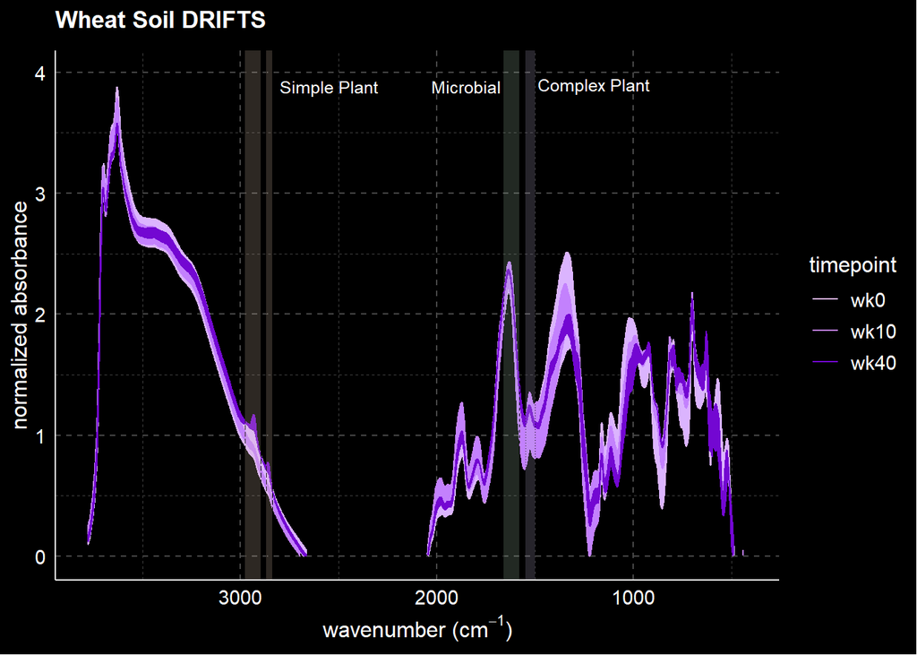

```r
# Define crop-specific color palettes
crop_timepoint_colors <- color_map_all_sep


# Generic function to create crop-specific DRIFTS plots
create_crop_plot <- function(data, crop_name, color_palette) {
  # Filter data for specific crop
  crop_data <- data %>%
    group_by(timepoint) %>%
    filter(crop == crop_name)

  # Ensure absorbance is numeric
  crop_data$snv_plusOne <- as.numeric(crop_data$snv_plusOne)

  # Create the plot
  crop_plot <- ggplot(crop_data,
                      aes(x = wavenumber,
                          y = snv_plusOne,
                          color = timepoint)) +
    xlim(3777, 422) +
    ylim(0, max(crop_data$snv_plusOne, na.rm = TRUE) + 0.1) +
    geom_line() +

    scale_color_manual(values = color_palette) +
    ggtitle(paste(str_to_title(crop_name), "Soil DRIFTS")) +
    labs(x = expression("wavenumber (cm"^-1*")"),
         y = "normalized absorbance") +
    geom_vline(xintercept = 1500, linetype = "dotted", linewidth = 0.3) +
    geom_vline(xintercept = 1550, linetype = "dotted", linewidth = 0.3) +
    geom_vline(xintercept = 1580, linetype = "dashed", linewidth = 0.23) +
    geom_vline(xintercept = 1660, linetype = "dashed", linewidth = 0.23) +
    geom_vline(xintercept = 2839, linetype = "longdash", linewidth = 0.23) +
    geom_vline(xintercept = 2870, linetype = "longdash", linewidth = 0.23) +
    geom_vline(xintercept = 2898, linetype = "longdash", linewidth = 0.23) +
    geom_vline(xintercept = 2976, linetype = "longdash", linewidth = 0.23) +
    # Add simple plant region annotation
    annotate("rect", xmin = 2976, xmax = 2898, ymin = -Inf, ymax = Inf,
             alpha = 0.2, fill = "#e3c8b1") +
    annotate("rect", xmin = 2870, xmax = 2839, ymin = -Inf, ymax = Inf,
             alpha = 0.2, fill = "#e3c8b1") +
    annotate("text", x = 2550, y = max(crop_data$snv_plusOne), label = "Simple Plant",
             size = 3.3, hjust = 0.5, color = annotation_text_color) +
    # Add microbial region annotation
    annotate("rect", xmin = 1660, xmax = 1580, ymin = -Inf, ymax = Inf,
             alpha = 0.2, fill = "#a8cbad") +
    annotate("text", x = 1850, y = max(crop_data$snv_plusOne), label = "Microbial",
             size = 3.3, hjust = 0.5, color = annotation_text_color) +
    # Add complex plant region annotation
    annotate("rect", xmin = 1550, xmax = 1500, ymin = -Inf, ymax = Inf,
             alpha = 0.2, fill = "#beb5d5") +
    annotate("text", x = 1200, y = max(crop_data$snv_plusOne)+0.02, label = "Complex Plant",
             size = 3.3, hjust = 0.5, color = annotation_text_color)

  return(list(plot = crop_plot, data = crop_data))
}

# Generic function to create crop ID tables
create_crop_id_table <- function(crop_data, crop_name) {
  combinations <- crop_data %>%
    select(ID, timepoint) %>%
    distinct() %>%
    arrange(ID, timepoint) %>%
    group_by(timepoint) %>%
    summarise(pot_ids = {
      ids <- paste(ID, sep = "")
      # Group every 3 items and join with line breaks
      grouped <- split(ids, ceiling(seq_along(ids)/5))
      lines <- sapply(grouped, function(x) paste(x, collapse = ",&ensp;"))
      paste(lines, collapse = "<br>")
    }, .groups = 'drop') %>%
    pivot_wider(names_from = timepoint, values_from = pot_ids)

  return(combinations)
}

# Generate plots and tables for each crop
crops <- c("wheat", "rice", "soy", "noPlant")

for (crop in crops) {
  # Create plot and get data
  result <- create_crop_plot(dpt_data_rhizo, crop, crop_timepoint_colors[[crop]])

  # Print the plot
  print(result$plot)
  cat("<br>")  # Add space between plot and table

  # Create and print ID combinations table
  id_table <- create_crop_id_table(result$data, crop)
  cat(paste0("<h4>", str_to_title(crop), " rhizosphere soil samples</h4>"))
  cat(knitr::kable(id_table, format = "html", escape = FALSE, table.attr = 'style="border-collapse: separate; border-spacing: 35px 0;"'))
  cat("<br><br>")  # Add HTML line breaks for spacing
}
```

#### Wheat rhizosphere soil samples

| wk0 | wk10 | wk40 |
| --- | --- | --- |
| 001, 024, 028, 032 | 029, 053, 109 | 029, 053, 109 |

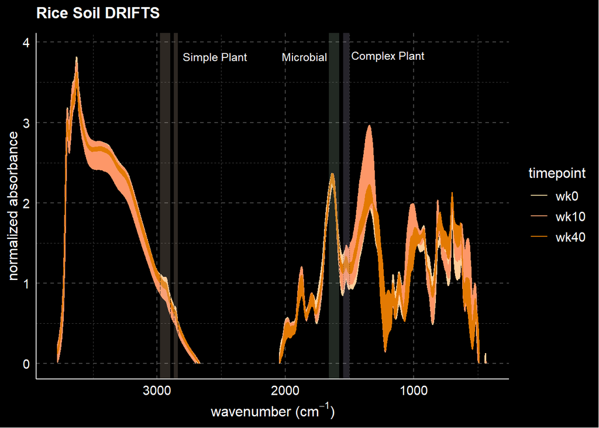

#### Rice rhizosphere soil samples

| wk0 | wk10 | wk40 |
| --- | --- | --- |
| 071, 103 | 055, 087, 119 | 055, 087, 119 |

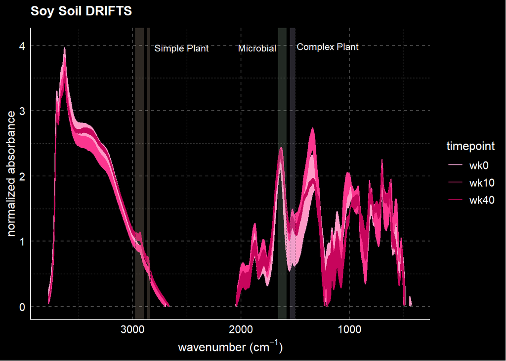

#### Soy rhizosphere soil samples

| wk0 | wk10 | wk40 |
| --- | --- | --- |
| 050, 062, 104 | 012, 080, 094 | 030, 080, 094 |

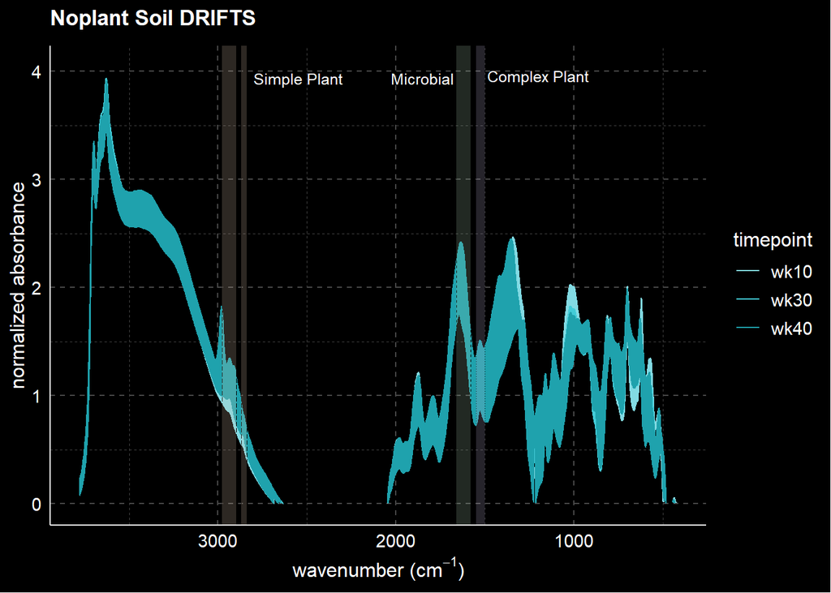

#### Noplant rhizosphere soil samples

| wk10 | wk30 | wk40 |
| --- | --- | --- |
| 044, 064, 072 | 020, 052 | 020, 044, 052, 064, 072 091, 108 |

# Combined stacked overlay plot

These chunks create a single visualization showing all crops and timepoints by stacking the overlay plots vertically with a shared y-axis. Each crop has its own color palette and legend.

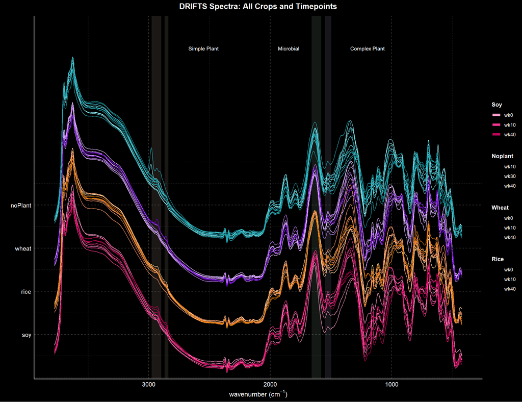

```r
# Define crop-specific color palettes (include noPlant)
crop_timepoint_colors_all <- color_map_all_sep


# Prepare data with all crops (ordered from bottom to top: noPlant, wheat, rice, soy)
crops_ordered <- c("soy", "rice", "wheat", "noPlant")  # Reversed for plotting so soy appears at top
all_crops_data <- dpt_data_rhizo   %>%
  filter(crop %in% crops_ordered) %>%
  mutate(crop = factor(crop, levels = crops_ordered)) %>%
  mutate(snv_plusOne = as.numeric(snv_plusOne))

# Calculate vertical offset for each crop to create stacking effect
offset_amount <- 1  # Space between each crop's spectra
crop_offsets <- setNames(seq(0, length(crops_ordered) - 1) * offset_amount, crops_ordered)

# Add offset to absorbance values based on crop
all_crops_data <- all_crops_data %>%
  mutate(offset_absorbance = snv_plusOne + crop_offsets[as.character(crop)])

# Determine max y position for annotations
max_y <- max(all_crops_data$offset_absorbance, na.rm = TRUE) + 0.2

# Create the base plot with functional region annotations
base_plot <- ggplot() +
  xlim(3777, 422) +

  labs(x = expression("wavenumber (cm"^-1*")"),
       y = "",
       title = "DRIFTS Spectra: All Crops and Timepoints") +
  theme(
    plot.title = element_text(hjust = 0.5, face = "bold", size = 14),
    axis.text.y = element_text(size = 11),
    axis.ticks.y = element_blank(),
    legend.position = "right",
    legend.box = "vertical",
    legend.spacing.y = unit(0.5, "cm"),
    legend.title = element_text(size = 10, face = "bold"),
    legend.text = element_text(size = 9)
  ) +
  scale_y_continuous(
    breaks = crop_offsets + offset_amount/2,
    labels = c("soy", "rice", "wheat", "noPlant"),
    expand = expansion(mult = c(0.02, 0.1))
  ) +
  # Add vertical lines for functional regions
  geom_vline(xintercept = 1500, linetype = "dotted", linewidth = 0.3) +
  geom_vline(xintercept = 1550, linetype = "dotted", linewidth = 0.3) +
  geom_vline(xintercept = 1580, linetype = "dashed", linewidth = 0.23) +
  geom_vline(xintercept = 1660, linetype = "dashed", linewidth = 0.23) +
  geom_vline(xintercept = 2839, linetype = "longdash", linewidth = 0.23) +
  geom_vline(xintercept = 2870, linetype = "longdash", linewidth = 0.23) +
  geom_vline(xintercept = 2898, linetype = "longdash", linewidth = 0.23) +
  geom_vline(xintercept = 2976, linetype = "longdash", linewidth = 0.23) +
  # Add shaded regions with annotations
  annotate("rect", xmin = 2976, xmax = 2898, ymin = -Inf, ymax = Inf,
           alpha = 0.12, fill = "#e3c8b1") +
  annotate("rect", xmin = 2870, xmax = 2839, ymin = -Inf, ymax = Inf,
           alpha = 0.12, fill = "#e3c8b1") +
  annotate("text", x = 2550, y = max_y, label = "Simple Plant",
           size = 3.3, hjust = 0.5, color = annotation_text_color) +
  annotate("rect", xmin = 1660, xmax = 1580, ymin = -Inf, ymax = Inf,
           alpha = 0.12, fill = "#a8cbad") +
  annotate("text", x = 1850, y = max_y, label = "Microbial",
           size = 3.3, hjust = 0.5, color = annotation_text_color) +
  annotate("rect", xmin = 1550, xmax = 1500, ymin = -Inf, ymax = Inf,
           alpha = 0.12, fill = "#beb5d5") +
  annotate("text", x = 1200, y = max_y, label = "Complex Plant",
           size = 3.3, hjust = 0.5, color = annotation_text_color)

# Install ggnewscale if needed for multiple color scales
if (!require(ggnewscale, quietly = TRUE)) {
  install.packages("ggnewscale")
  library(ggnewscale)
}

# Add each crop as a separate layer with its own color scale
combined_overlay_plot <- base_plot

for (crop in rev(crops_ordered)) {  # Add in reverse order so legends appear in correct order
  crop_data <- all_crops_data %>% filter(crop == !!crop)

  combined_overlay_plot <- combined_overlay_plot +
    geom_line(data = crop_data,
              aes(x = wavenumber,
                  y = offset_absorbance,
                  color = timepoint,
                  group = interaction(filename, timepoint)),
              show.legend = TRUE) +
    scale_color_manual(
      name = str_to_title(crop),
      values = crop_timepoint_colors_all[[crop]],
      guide = guide_legend(override.aes = list(linewidth = 2))
    ) +
    new_scale_color()  # Reset color scale for next crop
}

print(combined_overlay_plot)
```

## Showing average and range

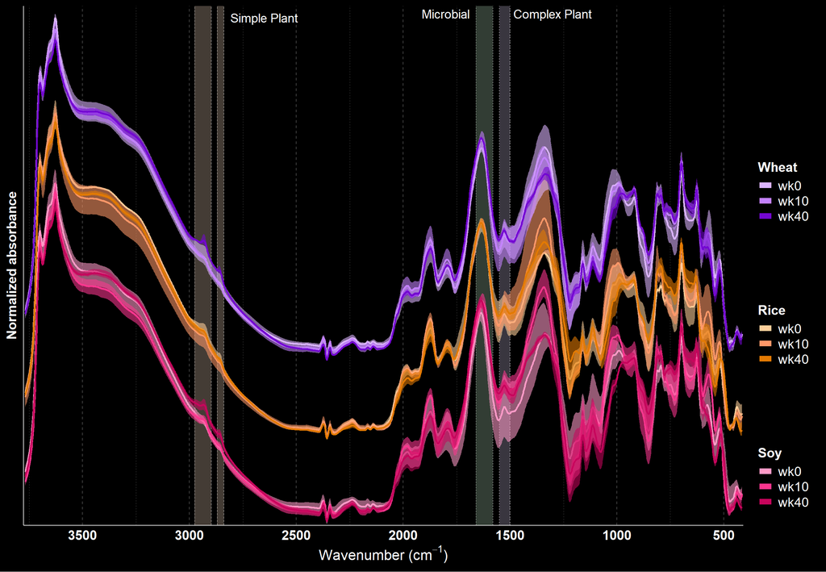

```r
crop_timepoint_colors_three <- color_map_three_sep

# Prepare data with three crops only (ordered from bottom to top: wheat, rice, soy)
crops_ordered_three <- c("soy", "rice", "wheat")  # Reversed for plotting so soy appears at top
three_crops_data <- dpt_data_rhizo %>%
  filter(crop %in% crops_ordered_three) %>%
  mutate(crop = factor(crop, levels = crops_ordered_three)) %>%
  mutate(snv_plusOne = as.numeric(snv_plusOne))

# Calculate vertical offset for each crop to create stacking effect
offset_amount_three <- 1  # Space between each crop's spectra
crop_offsets_three <- setNames(seq(0, length(crops_ordered_three) - 1) * offset_amount_three, crops_ordered_three)

# Add offset to absorbance values based on crop
three_crops_data <- three_crops_data %>%
  mutate(offset_absorbance = snv_plusOne + crop_offsets_three[as.character(crop)])

# Determine max y position for annotations
max_y_three <- max(three_crops_data$offset_absorbance, na.rm = TRUE)

# Create the base plot with functional region annotations
base_plot_range <- ggplot() +
  xlim(3777, 422) +

  labs(x = expression("Wavenumber (cm"^-1*")"),
       y = "Normalized absorbance") +
  theme(
    axis.text.y = element_blank(),
    # axis.ticks.y = element_blank(),
    axis.title.y = element_text(size = 15, face = "bold"),
    axis.text.x = element_text(size = 15, face = "bold"),
    axis.title.x = element_text(size = 16, face = "bold"),
    legend.position = "right",
    legend.justification = c(0, 0.07),  # (x, y) position; 0,0 is bottom-right
    legend.box = "vertical",
    legend.spacing.y = unit(2.8, "cm"),
    legend.title = element_text(size = 15, face = "bold"),
    legend.text = element_text(size = 14.5),
    plot.margin = margin(7, 14, 7, 7, "pt"),  # (top, right, bottom, left)
    panel.grid.major.y = element_blank(),
    panel.grid.minor.y = element_blank()
  ) +
  scale_y_continuous(
    breaks = crop_offsets_three + 0.003, # y-tick positions
    labels = NULL,
    expand = expansion(mult = c(0.003, 0.015)) # (bottom padding, top padding)
  ) +
  scale_x_reverse(
    limits = c(3770, 415),
    breaks = seq(3500, 500, -500),  # Ticks every 500 from 3500 down to 500
    expand = c(0.002, 0.003)  # Remove padding on x-axis
  ) +
  # Add vertical lines for functional regions
  geom_vline(xintercept = 1500, linetype = "dotted", linewidth = 0.46, color = annotation_text_color, alpha = 0.8) +
  geom_vline(xintercept = 1550, linetype = "dotted", linewidth = 0.46, color = annotation_text_color, alpha = 0.8) +
  geom_vline(xintercept = 1580, linetype = "dashed", linewidth = 0.23, color = annotation_text_color, alpha = 0.8) +
  geom_vline(xintercept = 1660, linetype = "dashed", linewidth = 0.23, color = annotation_text_color, alpha = 0.8) +
  geom_vline(xintercept = 2839, linetype = "longdash", linewidth = 0.23, color = annotation_text_color, alpha = 0.8) +
  geom_vline(xintercept = 2870, linetype = "longdash", linewidth = 0.23, color = annotation_text_color, alpha = 0.8) +
  geom_vline(xintercept = 2898, linetype = "longdash", linewidth = 0.23, color = annotation_text_color, alpha = 0.8) +
  geom_vline(xintercept = 2976, linetype = "longdash", linewidth = 0.23, color = annotation_text_color, alpha = 0.8) +
  # Add shaded regions with annotations
  annotate("rect", xmin = 2976, xmax = 2898, ymin = -Inf, ymax = Inf,
           alpha = 0.3, fill = "#e3c8b1") +
  annotate("rect", xmin = 2870, xmax = 2839, ymin = -Inf, ymax = Inf,
           alpha = 0.3, fill = "#e3c8b1") +
  annotate("text", x = 2650, y = max_y_three - 0.05, label = "Simple Plant",
           size = 4.9, face = "bold", hjust = 0.5, color = annotation_text_color) +
  annotate("rect", xmin = 1660, xmax = 1580, ymin = -Inf, ymax = Inf,
           alpha = 0.3, fill = "#a8cbad") +
  annotate("text", x = 1800, y = max_y_three, label = "Microbial",
           size = 4.9, face = "bold", hjust = 0.5, color = annotation_text_color) +
  annotate("rect", xmin = 1550, xmax = 1500, ymin = -Inf, ymax = Inf,
           alpha = 0.3, fill = "#beb5d5") +
  annotate("text", x = 1300, y = max_y_three, label = "Complex Plant",
           size = 4.9, face = "bold", hjust = 0.5, color = annotation_text_color)

# Add layers for each crop with average and range
combined_overlay_range_plot <- base_plot_range

for (crop in crops_ordered_three) {
  crop_data <- three_crops_data %>% filter(crop == !!crop)

  for (tp in names(crop_timepoint_colors_three[[crop]])) {
    tp_data <- crop_data %>% filter(timepoint == tp)

    # Calculate average and range for this crop+timepoint combination
    summary_data <- tp_data %>%
      group_by(wavenumber) %>%
      summarise(
        mean_absorbance = mean(offset_absorbance, na.rm = TRUE),
        min_absorbance = min(offset_absorbance, na.rm = TRUE),
        max_absorbance = max(offset_absorbance, na.rm = TRUE),
        .groups = "drop"
      )

    # Add range ribbon (semi-transparent)
    combined_overlay_range_plot <- combined_overlay_range_plot +
      geom_ribbon(data = summary_data,
                  aes(x = wavenumber, ymin = min_absorbance, ymax = max_absorbance),
                  fill = crop_timepoint_colors_three[[crop]][tp],
                  alpha = 0.58,
                  color = NA,
                  show.legend = FALSE)

    # Add average line (opaque)
    combined_overlay_range_plot <- combined_overlay_range_plot +
      geom_line(data = summary_data,
                aes(x = wavenumber, y = mean_absorbance),
                color = crop_timepoint_colors_three[[crop]][tp],
                linewidth = 0.88,
                alpha = 1,
                show.legend = FALSE)
  }
}

# Create dummy data for manual legends - one for each crop
dummy_wheat <- data.frame(
  x = rep(3777, 3), y = rep(0, 3),
  wheat_tp = names(crop_timepoint_colors_three$wheat)
)

dummy_rice <- data.frame(
  x = rep(3777, 3), y = rep(0, 3),
  rice_tp = names(crop_timepoint_colors_three$rice)
)

dummy_soy <- data.frame(
  x = rep(3777, 3), y = rep(0, 3),
  soy_tp = names(crop_timepoint_colors_three$soy)
)

# Add invisible layers with separate aesthetics for each crop
combined_overlay_range_plot <- combined_overlay_range_plot +
  # Wheat legend
  geom_line(data = dummy_wheat,
            aes(x = x, y = y, color = wheat_tp),
            linewidth = 0, alpha = 0) +
  scale_color_manual(
    name = "Wheat",
    values = crop_timepoint_colors_three$wheat,
    breaks = names(crop_timepoint_colors_three$wheat),
    labels = names(crop_timepoint_colors_three$wheat),
    guide = guide_legend(
      override.aes = list(linewidth = 3, alpha = 1),
      order = 1
    )
  ) +
  ggnewscale::new_scale_color() +
  # Rice legend
  geom_line(data = dummy_rice,
            aes(x = x, y = y, color = rice_tp),
            linewidth = 0, alpha = 0) +
  scale_color_manual(
    name = "Rice",
    values = crop_timepoint_colors_three$rice,
    breaks = names(crop_timepoint_colors_three$rice),
    labels = names(crop_timepoint_colors_three$rice),
    guide = guide_legend(
      override.aes = list(linewidth = 3, alpha = 1),
      order = 2
    )
  ) +
  ggnewscale::new_scale_color() +
  # Soy legend
  geom_line(data = dummy_soy,
            aes(x = x, y = y, color = soy_tp),
            linewidth = 0, alpha = 0) +
  scale_color_manual(
    name = "Soy",
    values = crop_timepoint_colors_three$soy,
    breaks = names(crop_timepoint_colors_three$soy),
    labels = names(crop_timepoint_colors_three$soy),
    guide = guide_legend(
      override.aes = list(linewidth = 3, alpha = 1),
      order = 3
    )
  )

print(combined_overlay_range_plot)
```

```r
ggsave_themed("combined_overlay_range_no_noplant.png", combined_overlay_range_plot, width = 13, height = 9, dpi = 300)
```

# Comparing regions of interest

## Integrating spectral regions

```r
# Function to perform spectral integration on DPT data (based on Leila_code_modified.Rmd)
perform_spectral_integration <- function(dpt_data) {
  cat("Starting spectral integration processing...\n")

  # Load required library for integration
  if (!require(pracma, quietly = TRUE)) {
    install.packages("pracma")
    library(pracma)
  }

  # Prepare the data in the format needed for integration
  # Rename columns to match expected format
  comb <- dpt_data %>%
    select(filename, wavenumber, absorbance) %>%
    rename(sample = filename, wavelength = wavenumber, abs = absorbance)

  # Define spectral windows of interest (same as Leila's code)
  red1 <- comb[comb$wavelength > 2839 & comb$wavelength < 2870, ]  # Aliphatic 1
  red2 <- comb[comb$wavelength > 2898 & comb$wavelength < 2976, ]  # Aliphatic 2
  red3 <- comb[comb$wavelength > 1580 & comb$wavelength < 1660, ]  # Microbial
  red4 <- comb[comb$wavelength > 1500 & comb$wavelength < 1550, ]  # Complex plant

  # Get unique samples
  sample <- unique(comb$sample)

  # Create integration results data frame
  ints <- data.frame(
    sample = sample,
    int_2839_2870 = numeric(length(sample)),
    int_2898_2976 = numeric(length(sample)),
    int_1580_1660 = numeric(length(sample)),
    int_1500_1550 = numeric(length(sample)),
    stringsAsFactors = FALSE
  )

  # Calculate integrated areas for each spectral window and sample
  cat("Processing", length(sample), "samples for integration...\n")
  for (i in seq_len(nrow(ints))) {
    current_sample <- sample[i]

    # Extract data for current sample from each spectral window
    sample_red1 <- red1[red1$sample == current_sample, ]
    sample_red2 <- red2[red2$sample == current_sample, ]
    sample_red3 <- red3[red3$sample == current_sample, ]
    sample_red4 <- red4[red4$sample == current_sample, ]

    # Calculate area under curve (integration) using trapezoidal rule
    if (nrow(sample_red1) > 1) {
      ints$int_2839_2870[i] <- pracma::trapz(sample_red1$wavelength, sample_red1$abs)
    }

    if (nrow(sample_red2) > 1) {
      ints$int_2898_2976[i] <- pracma::trapz(sample_red2$wavelength, sample_red2$abs)
    }

    if (nrow(sample_red3) > 1) {
      ints$int_1580_1660[i] <- pracma::trapz(sample_red3$wavelength, sample_red3$abs)
    }

    if (nrow(sample_red4) > 1) {
      ints$int_1500_1550[i] <- pracma::trapz(sample_red4$wavelength, sample_red4$abs)
    }
  }

  # Use existing metadata from the input data (no need to re-extract)
  cat("Using existing metadata from DPT data...\n")
  basic_meta <- dpt_data %>%
    select(filename, crop, timepoint, sample_type, ID) %>%
    distinct() %>%
    rename(sample = filename, type = sample_type)

  # Combine metadata with integration results
  ftir_data <- merge(basic_meta, ints, by = "sample", all = TRUE)

  # Rename integration columns to match expected names
  names(ftir_data)[names(ftir_data) == "int_1580_1660"] <- "int_microbial"
  names(ftir_data)[names(ftir_data) == "int_1500_1550"] <- "int_complex_plant"

  # Calculate derived metrics (same as original)
  ftir_data$aliphatic <- ftir_data$int_2839_2870 + ftir_data$int_2898_2976
  ftir_data$total_peak_area <- ftir_data$aliphatic + ftir_data$int_microbial + ftir_data$int_complex_plant
  ftir_data$simple_plant_prop <- ftir_data$aliphatic / ftir_data$total_peak_area
  ftir_data$complex_plant_prop <- ftir_data$int_complex_plant / ftir_data$total_peak_area
  ftir_data$microbial_prop <- ftir_data$int_microbial / ftir_data$total_peak_area
  ftir_data$simple_microbial_prop <- ftir_data$simple_plant_prop / ftir_data$microbial_prop
  ftir_data$complex_microbial_prop <- ftir_data$complex_plant_prop / ftir_data$microbial_prop

  # Remove individual aliphatic integration columns (keep only derived metrics)
  ftir_data <- ftir_data %>%
    select(-int_2839_2870, -int_2898_2976)

  # Save the processed data to the output directory
  today <- format(Sys.Date(), "%Y-%m-%d")
  output_file <- file.path(outputs_folder, paste0("processed_int_data_", today, ".csv"))
  write.csv(ftir_data, file = output_file, row.names = FALSE)
  cat("Saved processed integration data to:", output_file, "\n")

  cat("Integration processing completed successfully.\n")
  return(ftir_data)
}
```

## Generating statistics

```r
# Try to find the most recent processed integration data file
ftir_file <- find_most_recent_processed_file(outputs_folder)
```

```
## Found 1 processed integration files
## Using most recent file: processed_int_data_2026-07-07.csv
```

```r
if (!is.null(ftir_file) && file.exists(ftir_file)) {
  ftir_data <- read_csv(ftir_file, show_col_types = FALSE)
  cat("Successfully loaded FTIR integration data from:", basename(ftir_file), "\n")
  cat("Dimensions:", dim(ftir_data), "\n")
  cat("Columns:", names(ftir_data), "\n")
} else {
  cat("No processed integration data found. Processing raw DPT data to generate integration results...\n")

  # Check if we have the required dpt_data_rhizo from previous chunk
  if (!exists("dpt_data_rhizo") || nrow(dpt_data_rhizo) == 0) {
    stop("No DPT data available for integration. Please ensure the DPT data import was successful.")
  }

  # Process raw DPT data using the integrated function
  ftir_data <- perform_spectral_integration(dpt_data_rhizo)

  # Verify the processing was successful
  if (is.null(ftir_data) || nrow(ftir_data) == 0) {
    stop("Failed to process DPT data for integration.")
  }

  cat("Successfully processed", nrow(ftir_data), "samples from DPT data\n")
  cat("Generated columns:", names(ftir_data), "\n")
}
```

```
## Successfully loaded FTIR integration data from: processed_int_data_2026-07-07.csv
## Dimensions: 46 14
## Columns: sample crop timepoint type ID int_microbial int_complex_plant aliphatic total_peak_area simple_plant_prop complex_plant_prop microbial_prop simple_microbial_prop complex_microbial_prop
```

```r
# Calculate summary statistics by group
crop_stats <- ftir_data %>%
  mutate(crop = factor(crop, levels = c("noPlant", "wheat", "rice", "soy"))) %>%
  group_by(crop) %>%
  summarise(
    Mean_simple_plant_prop = mean(simple_plant_prop, na.rm = TRUE),
    SE_simple_plant_prop = sd(simple_plant_prop, na.rm = TRUE) / sqrt(n()),
    Mean_complex_plant_prop = mean(complex_plant_prop, na.rm = TRUE),
    SE_complex_plant_prop = sd(complex_plant_prop, na.rm = TRUE) / sqrt(n()),
    Mean_microbial_prop = mean(microbial_prop, na.rm = TRUE),
    SE_microbial_prop = sd(microbial_prop, na.rm = TRUE) / sqrt(n()),
    .groups = 'drop'
  )

timepoint_stats <- ftir_data %>%
  group_by(timepoint) %>%
  summarise(
    Mean_simple_plant_prop = mean(simple_plant_prop, na.rm = TRUE),
    SE_simple_plant_prop = sd(simple_plant_prop, na.rm = TRUE) / sqrt(n()),
    Mean_complex_plant_prop = mean(complex_plant_prop, na.rm = TRUE),
    SE_complex_plant_prop = sd(complex_plant_prop, na.rm = TRUE) / sqrt(n()),
    Mean_microbial_prop = mean(microbial_prop, na.rm = TRUE),
    SE_microbial_prop = sd(microbial_prop, na.rm = TRUE) / sqrt(n()),
    .groups = 'drop'
  )

crop_timepoint_stats <- ftir_data %>%
  mutate(crop = factor(crop, levels = c("noPlant", "wheat", "rice", "soy"))) %>%
  group_by(crop, timepoint) %>%
  summarise(
    Mean_simple_plant_prop = mean(simple_plant_prop, na.rm = TRUE),
    SE_simple_plant_prop = sd(simple_plant_prop, na.rm = TRUE) / sqrt(n()),
    Mean_complex_plant_prop = mean(complex_plant_prop, na.rm = TRUE),
    SE_complex_plant_prop = sd(complex_plant_prop, na.rm = TRUE) / sqrt(n()),
    Mean_microbial_prop = mean(microbial_prop, na.rm = TRUE),
    SE_microbial_prop = sd(microbial_prop, na.rm = TRUE) / sqrt(n()),
    .groups = 'drop'
  )
```

# Visualizing integrated ranges

This code is modified from “Visualizing_FTIR_w_Elemental_Data.R”

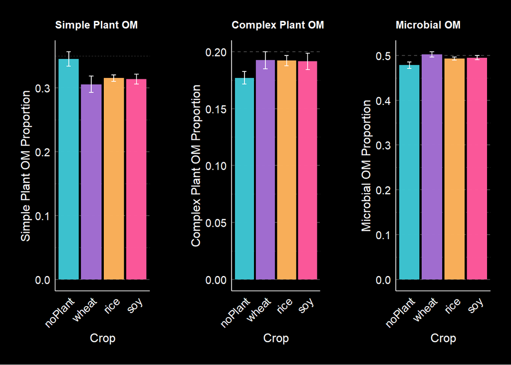

```r
# Recreate the EXACT plotting function from Leila_code_modified.Rmd
create_proportion_plots <- function(stats_data, group_col, title_prefix) {
  # Choose colors based on grouping variable
  colors_to_use <- if(group_col == "crop") crop_colors else timepoint_colors

  p1 <- ggplot(data = stats_data, aes_string(x = group_col, y = "Mean_simple_plant_prop", fill = group_col)) +
    geom_col(alpha = 0.98) +
    geom_errorbar(aes_string(ymin = "Mean_simple_plant_prop - SE_simple_plant_prop",
                            ymax = "Mean_simple_plant_prop + SE_simple_plant_prop"),
                  width = 0.2,
                  color = annotation_text_color) +

    scale_fill_manual(values = colors_to_use) +
    labs(title = paste0(title_prefix, "Simple Plant OM"),
         x = str_to_title(group_col),
         y = "Simple Plant OM Proportion") +
    theme(legend.position = "none",
          axis.text.x = element_text(angle = 45, hjust = 1),
          plot.margin = margin(20, 20, 20, 20),
          axis.title = element_text(size = 12),
          plot.title = element_text(size = 10),
          panel.grid.major.x = element_blank(),
          panel.grid.minor.x = element_blank())

  p2 <- ggplot(data = stats_data, aes_string(x = group_col, y = "Mean_complex_plant_prop", fill = group_col)) +
    geom_col(alpha = 0.98) +
    geom_errorbar(aes_string(ymin = "Mean_complex_plant_prop - SE_complex_plant_prop",
                            ymax = "Mean_complex_plant_prop + SE_complex_plant_prop"),
                  width = 0.2,
                  color = annotation_text_color) +

    scale_fill_manual(values = colors_to_use) +
    labs(title = paste0(title_prefix, "Complex Plant OM"),
         x = str_to_title(group_col),
         y = "Complex Plant OM Proportion") +
    theme(legend.position = "none",
          axis.text.x = element_text(angle = 45, hjust = 1),
          plot.margin = margin(20, 20, 20, 20),
          axis.title = element_text(size = 12),
          plot.title = element_text(size = 10),
          panel.grid.major.x = element_blank(),
          panel.grid.minor.x = element_blank())

  p3 <- ggplot(data = stats_data, aes_string(x = group_col, y = "Mean_microbial_prop", fill = group_col)) +
    geom_col(alpha = 0.98) +
    geom_errorbar(aes_string(ymin = "Mean_microbial_prop - SE_microbial_prop",
                            ymax = "Mean_microbial_prop + SE_microbial_prop"),
                  width = 0.2,
                  color = annotation_text_color) +

    scale_fill_manual(values = colors_to_use) +
    labs(title = paste0(title_prefix, "Microbial OM"),
         x = str_to_title(group_col),
         y = "Microbial OM Proportion") +
    theme(legend.position = "none",
          axis.text.x = element_text(angle = 45, hjust = 1),
          plot.margin = margin(20, 20, 20, 20),
          axis.title = element_text(size = 12),
          plot.title = element_text(size = 10),
          panel.grid.major.x = element_blank(),
          panel.grid.minor.x = element_blank())

  list(p1 = p1, p2 = p2, p3 = p3)
}

# Create EXACT plots by crop (from Leila_code_modified.Rmd)
crop_plots <- create_proportion_plots(crop_stats, "crop", "")
crop_combined <- plot_grid(crop_plots$p1, crop_plots$p2, crop_plots$p3, nrow = 1, labels = "auto")
print(crop_combined)
```

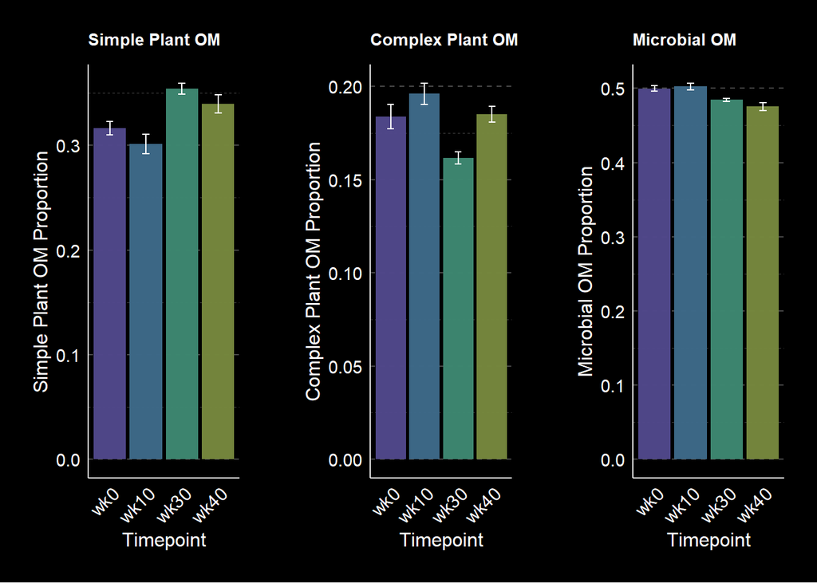

```r
# Create EXACT plots by timepoint (from Leila_code_modified.Rmd)
timepoint_plots <- create_proportion_plots(timepoint_stats, "timepoint", "")
timepoint_combined <- plot_grid(timepoint_plots$p1, timepoint_plots$p2, timepoint_plots$p3, nrow = 1, labels = "auto")
print(timepoint_combined)
```

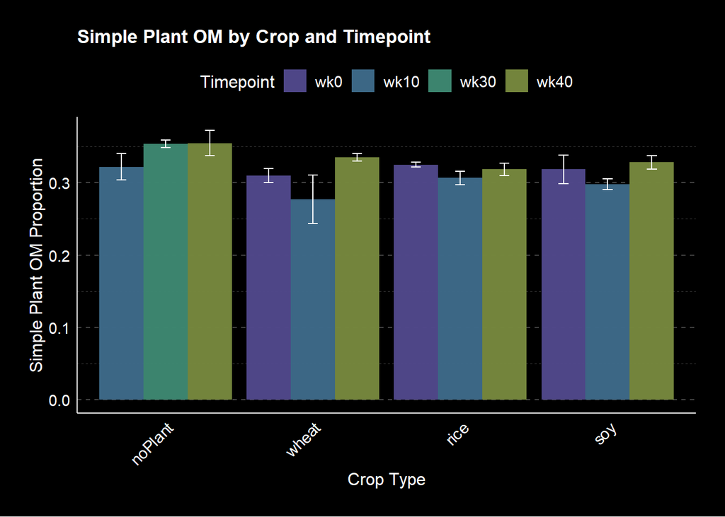

```r
# SIMPLE PLANT PROPORTION INTERACTION PLOT
# Recreate simple plant proportion interaction plot (crop x timepoint) from Leila_code_modified.Rmd
interaction_plot <- ggplot(crop_timepoint_stats) +
  geom_col(aes(x = crop, y = Mean_simple_plant_prop, fill = timepoint),
           position = "dodge", alpha = 0.98) +
  geom_errorbar(aes(x = crop,
                    ymin = Mean_simple_plant_prop - SE_simple_plant_prop,
                    ymax = Mean_simple_plant_prop + SE_simple_plant_prop,
                    group = timepoint),
                position = position_dodge(0.9), width = 0.2, color = annotation_text_color) +

  scale_fill_manual("Timepoint", values = timepoint_colors) +
  labs(title = "Simple Plant OM by Crop and Timepoint",
       x = "Crop Type",
       y = "Simple Plant OM Proportion") +
  theme(legend.position = "top",
        plot.margin = margin(20, 20, 20, 20),
        axis.text.x = element_text(angle = 45, hjust = 1),
        panel.grid.major.x = element_blank(),
        panel.grid.minor.x = element_blank())

print(interaction_plot)
```

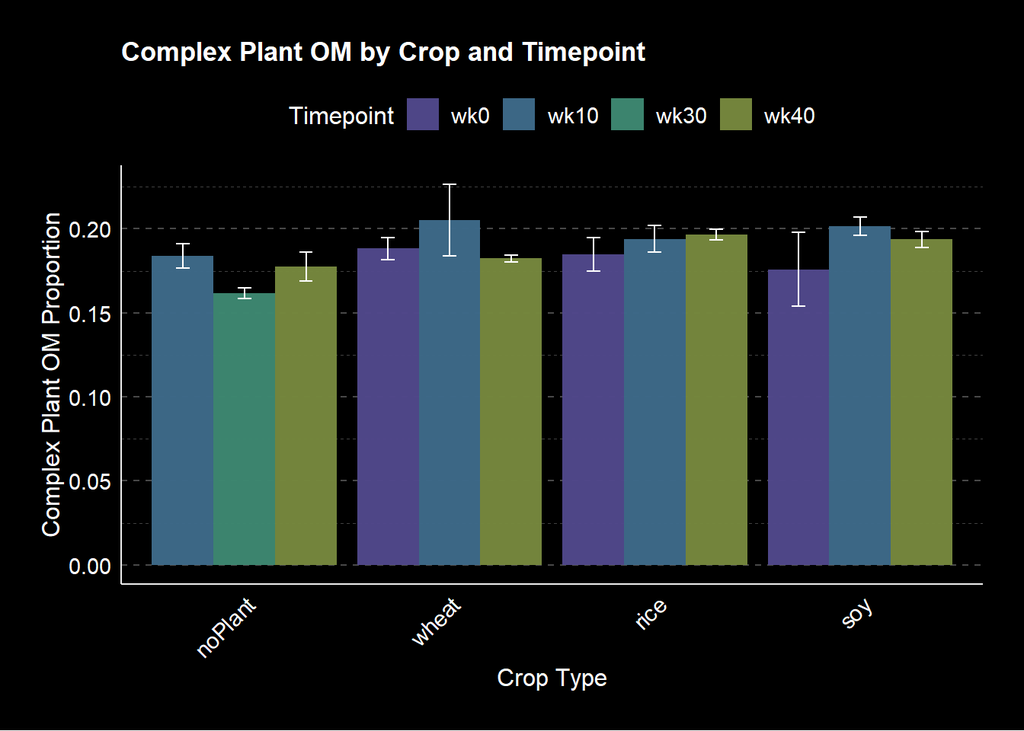

```r
# COMPLEX PLANT PROPORTION INTERACTION PLOT
CP_interaction_plot <- ggplot(crop_timepoint_stats) +
  geom_col(aes(x = crop, y = Mean_complex_plant_prop, fill = timepoint),
           position = "dodge", alpha = 0.98) +
  geom_errorbar(aes(x = crop,
                    ymin = Mean_complex_plant_prop - SE_complex_plant_prop,
                    ymax = Mean_complex_plant_prop + SE_complex_plant_prop,
                    group = timepoint),
                position = position_dodge(0.9), width = 0.2, color = annotation_text_color) +

  scale_fill_manual("Timepoint", values = timepoint_colors) +
  labs(title = "Complex Plant OM by Crop and Timepoint",
       x = "Crop Type",
       y = "Complex Plant OM Proportion") +
  theme(legend.position = "top",
        plot.margin = margin(20, 20, 20, 20),
        axis.text.x = element_text(angle = 45, hjust = 1),
        panel.grid.major.x = element_blank(),
        panel.grid.minor.x = element_blank())

print(CP_interaction_plot)
```

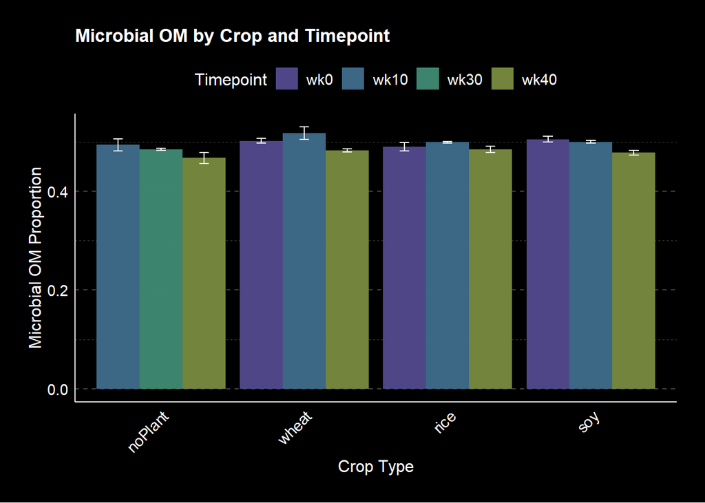

```r
# MICROBIAL PROPORTION INTERACTION PLOT
micr_interaction_plot <- ggplot(crop_timepoint_stats) +
  geom_col(aes(x = crop, y = Mean_microbial_prop, fill = timepoint),
           position = "dodge", alpha = 0.98) +
  geom_errorbar(aes(x = crop,
                    ymin = Mean_microbial_prop - SE_microbial_prop,
                    ymax = Mean_microbial_prop + SE_microbial_prop,
                    group = timepoint),
                position = position_dodge(0.9), width = 0.2, color = annotation_text_color) +

  scale_fill_manual("Timepoint", values = timepoint_colors) +
  labs(title = "Microbial OM by Crop and Timepoint",
       x = "Crop Type",
       y = "Microbial OM Proportion") +
  theme(legend.position = "top",
        plot.margin = margin(20, 20, 20, 20),
        axis.text.x = element_text(angle = 45, hjust = 1),
        panel.grid.major.x = element_blank(),
        panel.grid.minor.x = element_blank())

print(micr_interaction_plot)
```

## Stacked interaction plots (crop x timepoint)

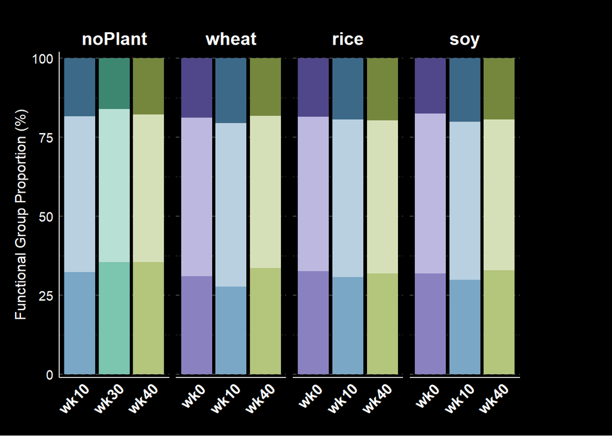

```r
timepoint_prop_colors <- list(
  "wk0" = c("Simple Plant" = "#8a82c0", "Microbial" = "#bdb8e0", "Complex Plant" = "#50478A"),
  "wk10" = c("Simple Plant" = "#7ba7c6", "Microbial" = "#b8d0e0", "Complex Plant" = "#3D6988"),
  "wk20" = c("Simple Plant" = "#c5aa7c", "Microbial" = "#e0d1b8", "Complex Plant" = "#876B3D"),
  "wk30" = c("Simple Plant" = "#7cc5af", "Microbial" = "#b8e0d4", "Complex Plant" = "#3D8770"),
  "wk40" = c("Simple Plant" = "#b4c57c", "Microbial" = "#d6e0b8", "Complex Plant" = "#75873D")
)

# Stacked interaction plot - crop x timepoint with all three proportions
# Create stacked data for interaction plot
interaction_stacked_data <- crop_timepoint_stats %>%
  select(crop, timepoint, Mean_simple_plant_prop, Mean_complex_plant_prop, Mean_microbial_prop) %>%
  pivot_longer(cols = starts_with("Mean_"),
               names_to = "func_type",
               values_to = "proportion") %>%
  mutate(func_type = case_when(
    func_type == "Mean_simple_plant_prop" ~ "Simple Plant",
    func_type == "Mean_microbial_prop" ~ "Microbial",
    func_type == "Mean_complex_plant_prop" ~ "Complex Plant"
  )) %>%
  mutate(func_type = factor(func_type, levels = c("Simple Plant", "Microbial", "Complex Plant")))

# Create a combined group for positioning (crop:timepoint)
interaction_stacked_data <- interaction_stacked_data %>%
  mutate(crop_time = interaction(crop, timepoint, sep = "_"))

# Apply colors - using average of timepoint colors for each functional group
# Or better - use timepoint-specific colors from timepoint_prop_colors
# Create fill based on timepoint:func_type combination
interaction_stacked_data <- interaction_stacked_data %>%
  mutate(fill_group = paste(timepoint, func_type, sep = "_"))

interaction_plot_stacked <- ggplot(interaction_stacked_data,
                                   aes(x = interaction(crop, timepoint),
                                       y = proportion * 100,
                                       fill = fill_group)) +
  geom_col(position = "stack") +
  facet_grid(. ~ crop, scales = "free_x", space = "free_x") +
  scale_x_discrete(labels = function(x) {
    # Extract just the timepoint part (after the dot)
    sapply(strsplit(as.character(x), "\\."), function(parts) parts[2])
  }) +
  scale_y_continuous(expand = expansion(mult = c(0.01, 0.02))) +

  labs(title = "",
       x = "",
       y = "Functional Group Proportion (%)",
       fill = "") +
  theme(legend.position = "right",
        plot.margin = margin(-2, 76, 0, 12), # (top, right, bottom, left)
        axis.text.x = element_text(angle = 45, hjust = .9, size = 12.5, face = "bold"),
        axis.title.y = element_text(size = 12),
        axis.text.y = element_text(size = 11),
        strip.background = element_blank(),
        strip.text = element_text(size = 14.5, face = "bold", color = annotation_text_color),
        panel.grid.major.x = element_blank(),
        panel.grid.minor.x = element_blank()
        ) +
  coord_cartesian(clip = "off")

# Create manual color scale using timepoint_prop_colors
color_values <- c()
color_names <- c()
for (tp in c("wk0", "wk10", "wk20", "wk30", "wk40")) {
  for (ft in c("Simple Plant", "Microbial", "Complex Plant")) {
    color_names <- c(color_names, paste(tp, ft, sep = "_"))
    color_values <- c(color_values, timepoint_prop_colors[[tp]][ft])
  }
}
names(color_values) <- color_names

interaction_plot_stacked <- interaction_plot_stacked +
  scale_fill_manual(values = color_values,
                    labels = function(x) {
                      parts <- strsplit(x, "_")
                      sapply(parts, function(p) paste(p[1], p[2], sep = " - "))
                    }) +
  theme(legend.position = "none",
        panel.grid.major.x = element_blank(),
        panel.grid.minor.x = element_blank())

# Calculate label positions (midpoint of each segment in the rightmost bar)
# Get the rightmost crop-timepoint combination for labeling
label_data <- interaction_stacked_data %>%
  filter(crop == "soy" & timepoint == "wk40") %>%
  arrange(func_type) %>%
  mutate(
    # Calculate cumulative sum for positioning
    cum_prop = cumsum(proportion * 100),
    # Calculate midpoint of each segment
    label_y = cum_prop - (proportion * 100) / 2
  )

# Add labels on the right side
interaction_plot_stacked <- interaction_plot_stacked +
  geom_text(data = label_data,
            aes(x = interaction(crop, timepoint),
                y = label_y,
                label = func_type),
            hjust = 0,
            nudge_x = 0.5,
            size = 3.8,
            angle = 10,
            fontface = "bold",
            inherit.aes = FALSE)

print(interaction_plot_stacked)
```

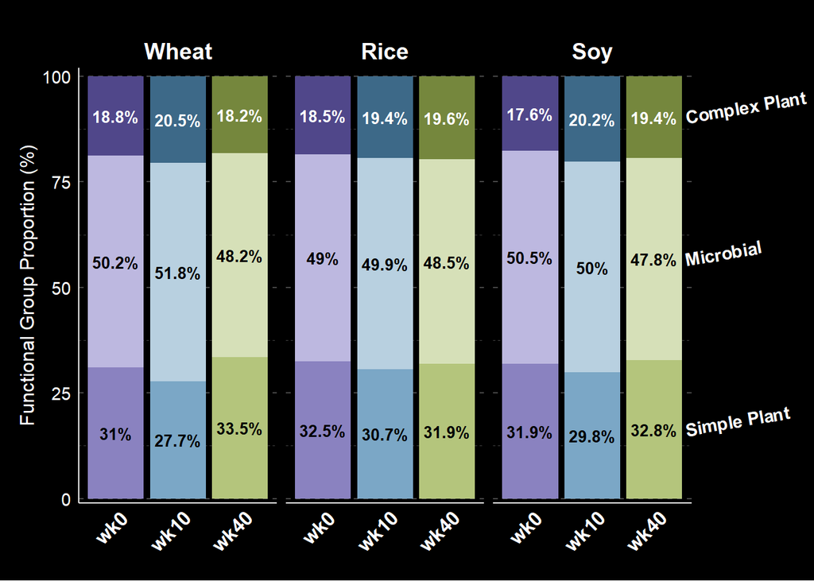

```r
# Stacked interaction plot - crop x timepoint (without noPlant)
# Create stacked data for interaction plot
interaction_stacked_data_no_noPlant <- crop_timepoint_stats %>%
  filter(crop != "noPlant") %>%
  select(crop, timepoint, Mean_simple_plant_prop, Mean_complex_plant_prop, Mean_microbial_prop) %>%
  pivot_longer(cols = starts_with("Mean_"),
               names_to = "func_type",
               values_to = "proportion") %>%
  mutate(func_type = case_when(
    func_type == "Mean_simple_plant_prop" ~ "Simple Plant",
    func_type == "Mean_microbial_prop" ~ "Microbial",
    func_type == "Mean_complex_plant_prop" ~ "Complex Plant"
  )) %>%
  mutate(func_type = factor(func_type, levels = c("Simple Plant", "Microbial", "Complex Plant")))

# Create a combined group for positioning (crop:timepoint)
interaction_stacked_data_no_noPlant <- interaction_stacked_data_no_noPlant %>%
  mutate(crop_time = interaction(crop, timepoint, sep = "_"))

# Create fill based on timepoint:func_type combination
interaction_stacked_data_no_noPlant <- interaction_stacked_data_no_noPlant %>%
  mutate(fill_group = paste(timepoint, func_type, sep = "_"))

interaction_plot_stacked_no_noPlant <- ggplot(interaction_stacked_data_no_noPlant,
                                   aes(x = interaction(crop, timepoint),
                                       y = proportion * 100,
                                       fill = fill_group)) +
  geom_col(position = "stack") +
  facet_grid(. ~ crop, scales = "free_x", space = "free_x",
             labeller = labeller(crop = c("wheat" = "Wheat", "rice" = "Rice", "soy" = "Soy"))) +
  scale_x_discrete(labels = function(x) {
    # Extract just the timepoint part (after the dot)
    sapply(strsplit(as.character(x), "\\."), function(parts) parts[2])
  }) +
  scale_y_continuous(expand = expansion(mult = c(0.01, 0.02))) +

  labs(title = "",
       x = "",
       y = "Functional Group Proportion (%)",
       fill = "") +
  theme(legend.position = "right",
        plot.margin = margin(-2, 76, 0, 12), # (top, right, bottom, left)
        axis.text.x = element_text(angle = 45, hjust = .9, size = 12.5, face = "bold"),
        axis.title.y = element_text(size = 12),
        axis.text.y = element_text(size = 11),
        strip.background = element_blank(),
        strip.text = element_text(size = 14, face = "bold", color = annotation_text_color)) +
  coord_cartesian(clip = "off")

# Create manual color scale using timepoint_prop_colors
interaction_plot_stacked_no_noPlant <- interaction_plot_stacked_no_noPlant +
  scale_fill_manual(values = color_values,
                    labels = function(x) {
                      parts <- strsplit(x, "_")
                      sapply(parts, function(p) paste(p[1], p[2], sep = " - "))
                    }) +
  theme(legend.position = "none",
        panel.grid.major.x = element_blank(),
        panel.grid.minor.x = element_blank())

# Calculate label positions (midpoint of each segment for ALL bars)
# Calculate cumulative proportions for positioning percentage labels
label_data_no_noPlant <- interaction_stacked_data_no_noPlant %>%
  group_by(crop, timepoint) %>%
  arrange(func_type) %>%
  mutate(
    # Calculate cumulative sum for positioning
    cum_prop = cumsum(proportion * 100),
    # Calculate midpoint of each segment
    label_y = cum_prop - (proportion * 100) / 2,
    # Create percentage label
    pct_label = paste0(round(proportion * 100, 1), "%"),
    # Assign label color: black for Microbial (light), white for others (darker)
    # label_color = ifelse(func_type == "Microbial", "black", "white")
    label_color = ifelse(func_type == "Complex Plant", "white", "black")
  ) %>%
  ungroup()

# Create label data for func_type labels (rightmost bar only)
functype_label_data <- label_data_no_noPlant %>%
  filter(crop == "soy" & timepoint == "wk40")

# Add percentage labels to all bars
interaction_plot_stacked_no_noPlant <- interaction_plot_stacked_no_noPlant +
  geom_text(data = label_data_no_noPlant,
            aes(x = interaction(crop, timepoint),
                y = label_y,
                label = pct_label,
                color = label_color),
            size = 3.5,
            fontface = "bold",
            inherit.aes = FALSE) +
  scale_color_identity() +  # Use the actual color values from label_color
  # Add func_type labels on the right side
  geom_text(data = functype_label_data,
            aes(x = interaction(crop, timepoint),
                y = label_y,
                label = func_type),
            hjust = 0,
            nudge_x = 0.5,
            size = 3.8,
            angle = 10,
            fontface = "bold",
            color = annotation_text_color,
            inherit.aes = FALSE)

print(interaction_plot_stacked_no_noPlant)
```

```r
ggsave_themed("stacked_interaction_plot_no_noPlant.png", interaction_plot_stacked_no_noPlant, width = 10, height = 6)
```

## Simple and Total Plant : Microbial Ratios Over Time

These scatterplots show the ratios of organic matter functional groups over the incubation period. Each point represents the mean ratio for a crop at a given timepoint, with error bars showing the standard error. Linear regression lines for each crop are shown with corresponding r² and p-values displayed in each crop’s color.

## Data preparation and regression analysis

```r
# Calculate total plant : microbial ratio (simple + complex) for each sample
ftir_data <- ftir_data %>%
  mutate(
    total_plant_prop = simple_plant_prop + complex_plant_prop,
    total_plant_microbial_prop = total_plant_prop / microbial_prop,
    simple_complex_prop = simple_plant_prop / complex_plant_prop
  )

# Create summary statistics by crop and timepoint for ratio metrics
# Convert timepoint to numeric for regression (wk0 = 0, wk10 = 10, etc.)
ratio_stats <- ftir_data %>%
  filter(crop %in% c("wheat", "rice", "soy")) %>%  # Exclude noPlant
  mutate(
    crop = factor(crop, levels = c("wheat", "rice", "soy")),
    timepoint_numeric = as.numeric(str_extract(timepoint, "\\d+"))
  ) %>%
  group_by(crop, timepoint, timepoint_numeric) %>%
  summarise(
    Mean_simple_microbial = mean(simple_microbial_prop, na.rm = TRUE),
    SE_simple_microbial = sd(simple_microbial_prop, na.rm = TRUE) / sqrt(n()),
    Mean_total_microbial = mean(total_plant_microbial_prop, na.rm = TRUE),
    SE_total_microbial = sd(total_plant_microbial_prop, na.rm = TRUE) / sqrt(n()),
    Mean_simple_complex = mean(simple_complex_prop, na.rm = TRUE),
    SE_simple_complex = sd(simple_complex_prop, na.rm = TRUE) / sqrt(n()),
    .groups = 'drop'
  )

# Calculate regression statistics for each crop (simple : microbial ratio)
# Using all individual data points, not just the 3 averaged points
simple_micr_regression_stats <- data.frame()
for (crop_name in c("wheat", "rice", "soy")) {
  crop_data <- ftir_data %>%
    filter(crop == crop_name) %>%
    mutate(timepoint_numeric = as.numeric(str_extract(timepoint, "\\d+")))

  if (nrow(crop_data) > 1) {
    model <- lm(simple_microbial_prop ~ timepoint_numeric, data = crop_data)
    summary_model <- summary(model)

    r_squared <- summary_model$r.squared
    p_value <- summary_model$coefficients[2, 4]
    intercept <- coef(model)[1]
    slope <- coef(model)[2]

    simple_micr_regression_stats <- rbind(simple_micr_regression_stats,
      data.frame(
        crop = crop_name,
        r_squared = r_squared,
        p_value = p_value,
        intercept = intercept,
        slope = slope
      )
    )
  }
}

# Calculate regression statistics for each crop (total plant : microbial ratio)
# Using all individual data points, not just the 3 averaged points
total_micr_regression_stats <- data.frame()
for (crop_name in c("wheat", "rice", "soy")) {
  crop_data <- ftir_data %>%
    filter(crop == crop_name) %>%
    mutate(timepoint_numeric = as.numeric(str_extract(timepoint, "\\d+")))

  if (nrow(crop_data) > 1) {
    model <- lm(total_plant_microbial_prop ~ timepoint_numeric, data = crop_data)
    summary_model <- summary(model)

    r_squared <- summary_model$r.squared
    p_value <- summary_model$coefficients[2, 4]
    intercept <- coef(model)[1]
    slope <- coef(model)[2]

    total_micr_regression_stats <- rbind(total_micr_regression_stats,
      data.frame(
        crop = crop_name,
        r_squared = r_squared,
        p_value = p_value,
        intercept = intercept,
        slope = slope
      )
    )
  }
}

# Calculate regression statistics for each crop (simple plant : complex plant ratio)
# Using all individual data points, not just the 3 averaged points
simple_complex_regression_stats <- data.frame()
for (crop_name in c("wheat", "rice", "soy")) {
  crop_data <- ftir_data %>%
    filter(crop == crop_name) %>%
    mutate(timepoint_numeric = as.numeric(str_extract(timepoint, "\\d+")))

  if (nrow(crop_data) > 1) {
    model <- lm(simple_complex_prop ~ timepoint_numeric, data = crop_data)
    summary_model <- summary(model)

    r_squared <- summary_model$r.squared
    p_value <- summary_model$coefficients[2, 4]
    intercept <- coef(model)[1]
    slope <- coef(model)[2]

    simple_complex_regression_stats <- rbind(simple_complex_regression_stats,
      data.frame(
        crop = crop_name,
        r_squared = r_squared,
        p_value = p_value,
        intercept = intercept,
        slope = slope
      )
    )
  }
}
```

## Ratio scatterplots with regression statistics

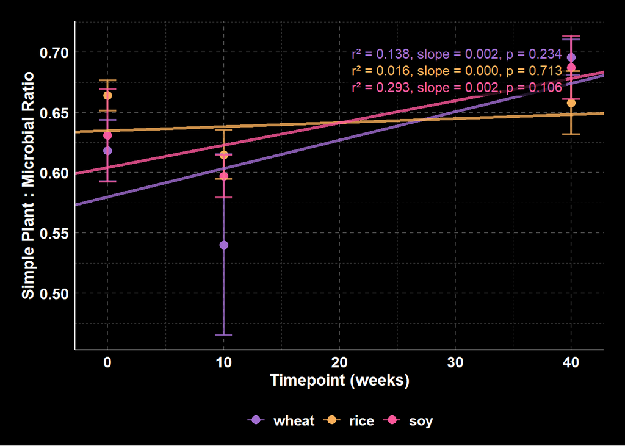

```r
# Function to create ratio scatterplot with regression lines and statistics
create_ratio_scatterplot <- function(data, y_metric, y_metric_se, title, y_label, regression_stats, crop_colors) {
  plot <- ggplot(data, aes(x = timepoint_numeric, y = !!sym(y_metric), color = crop)) +
    geom_point(size = 3, alpha = 0.98) +
    geom_errorbar(aes(ymin = !!sym(y_metric) - !!sym(y_metric_se),
                      ymax = !!sym(y_metric) + !!sym(y_metric_se)),
                  width = 1.5, alpha = 0.73, linewidth = 0.8) +

    scale_color_manual(values = crop_colors) +
    labs(title = title,
         x = "Timepoint (weeks)",
         y = y_label,
         color = "Crop") +
    theme(
      legend.position = "bottom",
      legend.title = element_blank(),
      legend.text = element_text(size = 11.5, face = "bold"),
      axis.text = element_text(size = 12, face = "bold"),
      axis.title = element_text(size = 13, face = "bold"),
      plot.title = element_blank(),
      plot.margin = margin(17, 17, 7, 17)
    )

  # Get data range for positioning
  max_x <- max(data$timepoint_numeric, na.rm = TRUE)
  min_x <- min(data$timepoint_numeric, na.rm = TRUE)
  max_y <- max(data[[y_metric]], na.rm = TRUE)
  min_y <- min(data[[y_metric]], na.rm = TRUE)
  y_range <- max_y - min_y

  # Create data frame to store all labels
  labels_df <- data.frame(
    label_x = numeric(),
    label_y = numeric(),
    label_text = character(),
    crop_color = character(),
    label_fontface = character(),
    stringsAsFactors = FALSE
  )

  # Add regression lines and statistics for each crop
  for (i in seq_len(nrow(regression_stats))) {
    reg_row <- regression_stats[i, ]
    crop_name <- reg_row$crop
    slope <- reg_row$slope
    intercept <- reg_row$intercept
    r_sq <- reg_row$r_squared
    p_val <- reg_row$p_value
    crop_color <- crop_colors[crop_name]

    # Add regression line
    plot <- plot +
      geom_abline(intercept = intercept, slope = slope,
                  color = crop_color, linewidth = 1.2, alpha = 0.8, linetype = "solid")

    # Position R² and p-value labels at top-right with staggered y positions
    label_x <- min_x + (max_x - min_x) * 0.99
    crop_order <- match(crop_name, c("wheat", "rice", "soy"))
    label_y <- max_y - (crop_order - 1.27) * (y_range * 0.09)

    # Format p-value and determine if significant
    p_significant <- p_val < 0.05
    if (p_val < 0.001) {
      p_label <- "p < 0.001"
    } else {
      p_label <- paste0("p = ", format(round(p_val, 3), nsmall = 3))
    }

    # Add star if p < 0.05 and set formatting
    p_label_with_star <- if (p_significant) paste0(p_label, "*") else p_label
    label_fontface <- if (p_significant) "bold" else "plain"

    # Create label with r², slope, and p-value
    label_text <- paste0("r² = ", format(round(r_sq, 3), nsmall = 3), ", slope = ", format(round(slope, 3), nsmall = 3), ", ", p_label_with_star)

    # Add to labels data frame
    labels_df <- rbind(labels_df, data.frame(
      label_x = label_x,
      label_y = label_y,
      label_text = label_text,
      crop_color = crop_color,
      label_fontface = label_fontface,
      stringsAsFactors = FALSE
    ))
  }

  # Add all labels at once after the loop
  plot <- plot +
    geom_label(data = labels_df,
               aes(x = label_x, y = label_y, label = label_text, color = I(crop_color), fontface = I(label_fontface)),
               fill = annotation_fill_color,
               alpha = 0.77,
               label.size = 0,
               label.color = NA,
               hjust = 1, # Align text to the right
               inherit.aes = FALSE,
               show.legend = FALSE)

  return(plot)
}

# Create Simple Plant : Microbial Ratio scatterplot
simple_micr_plot <- create_ratio_scatterplot(
  data = ratio_stats,
  y_metric = "Mean_simple_microbial",
  y_metric_se = "SE_simple_microbial",
  title = "",
  y_label = "Simple Plant : Microbial Ratio",
  regression_stats = simple_micr_regression_stats,
  crop_colors = crop_colors
)

print(simple_micr_plot)
```

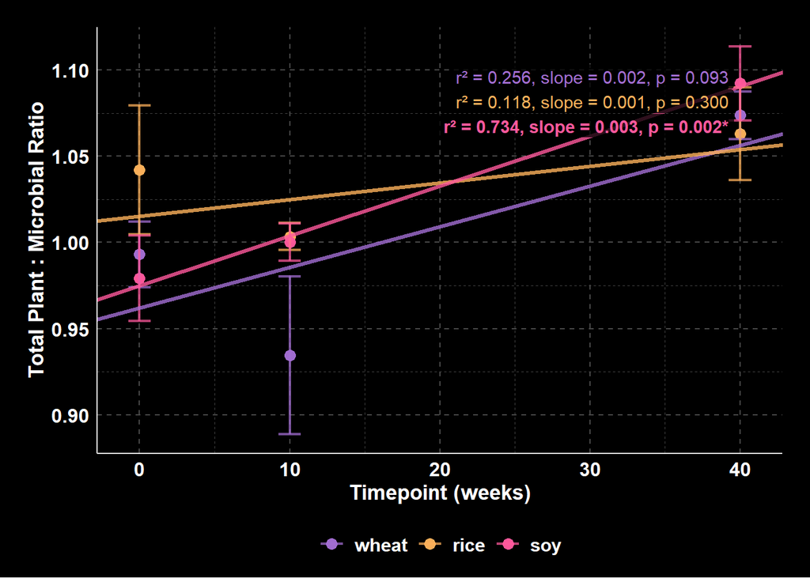

```r
ggsave_themed("simple_plant_microbial_ratio_scatterplot.png", simple_micr_plot)

# Create Total Plant : Microbial Ratio scatterplot
total_micr_plot <- create_ratio_scatterplot(
  data = ratio_stats,
  y_metric = "Mean_total_microbial",
  y_metric_se = "SE_total_microbial",
  title = "",
  y_label = "Total Plant : Microbial Ratio",
  regression_stats = total_micr_regression_stats,
  crop_colors = crop_colors
)

print(total_micr_plot)
```

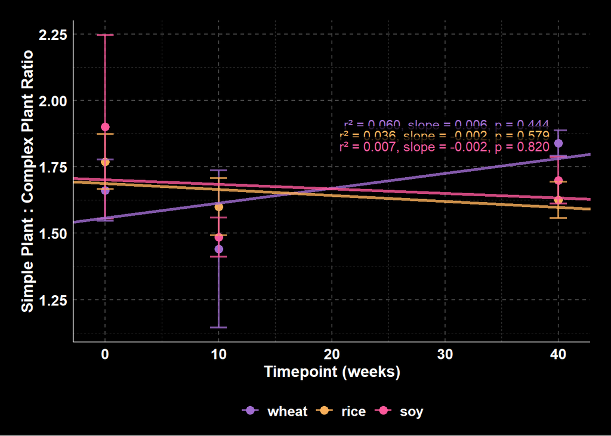

```r
ggsave_themed("total_plant_microbial_ratio_scatterplot.png", total_micr_plot)

# Create Simple Plant : Complex Plant Ratio scatterplot
simple_complex_plot <- create_ratio_scatterplot(
  data = ratio_stats,
  y_metric = "Mean_simple_complex",
  y_metric_se = "SE_simple_complex",
  title = "",
  y_label = "Simple Plant : Complex Plant Ratio",
  regression_stats = simple_complex_regression_stats,
  crop_colors = crop_colors
)

print(simple_complex_plot)
```

```r
ggsave_themed("simple_complex_ratio_scatterplot.png", simple_complex_plot)
```

# Summary

```r
# Print summary information
cat("Summary of FTIR Analysis:\n")
```

```
## Summary of FTIR Analysis:
```

```r
cat("Number of samples:", nrow(ftir_data), "\n")
```

```
## Number of samples: 46
```

```r
cat("Crops:", paste(unique(ftir_data$crop), collapse = ", "), "\n")
```

```
## Crops: wheat, soy, noPlant, rice
```

```r
cat("Timepoints:", paste(unique(ftir_data$timepoint), collapse = ", "), "\n")
```

```
## Timepoints: wk0, wk10, wk30, wk40
```

```r
# Display summary statistics
print("Crop Statistics:")
```

```
## [1] "Crop Statistics:"
```

```r
print(crop_stats)
```

```
## # A tibble: 4 × 7
##   crop    Mean_simple_plant_prop SE_simple_plant_prop Mean_complex_plant_prop
##   <fct>                    <dbl>                <dbl>                   <dbl>
## 1 noPlant                  0.345              0.0114                    0.177
## 2 wheat                    0.305              0.0128                    0.192
## 3 rice                     0.315              0.00515                   0.192
## 4 soy                      0.313              0.00761                   0.191
## # ℹ 3 more variables: SE_complex_plant_prop <dbl>, Mean_microbial_prop <dbl>,
## #   SE_microbial_prop <dbl>
```

```r
print("\nTimepoint Statistics:")
```

```
## [1] "\nTimepoint Statistics:"
```

```r
print(timepoint_stats)
```

```
## # A tibble: 4 × 7
##   timepoint Mean_simple_plant_prop SE_simple_plant_prop Mean_complex_plant_prop
##   <chr>                      <dbl>                <dbl>                   <dbl>
## 1 wk0                        0.316              0.00662                   0.184
## 2 wk10                       0.301              0.00945                   0.196
## 3 wk30                       0.354              0.00536                   0.162
## 4 wk40                       0.340              0.00861                   0.185
## # ℹ 3 more variables: SE_complex_plant_prop <dbl>, Mean_microbial_prop <dbl>,
## #   SE_microbial_prop <dbl>
```

```r
# Check if snv_plusOne exists and what it looks like
dpt_data_rhizo %>%
  filter(wavenumber > 2918 & wavenumber < 2928) %>%
  select(filename, wavenumber, absorbance, baseline_corrected, snv_plusOne) %>%
  group_by(filename) %>%
  summarise(
    n_points = n(),
    min_norm = min(snv_plusOne, na.rm = TRUE),
    max_norm = max(snv_plusOne, na.rm = TRUE),
    mean_norm = mean(snv_plusOne, na.rm = TRUE)
  ) %>%
  head()
```

```
## # A tibble: 6 × 5
##   filename                                  n_points min_norm max_norm mean_norm
##   <chr>                                        <int>    <dbl>    <dbl>     <dbl>
## 1 DRIFTS_Pot001_13Cwheat_wk0_rhizoSoil_260…        8    0.984    1.02      1.01
## 2 DRIFTS_Pot012_13Csoy_wk10_rhizoSoil_2606…        8    0.772    0.830     0.804
## 3 DRIFTS_Pot020_12CnoPlant_wk30_rhizoSoil_…        8    0.972    1.02      0.997
## 4 DRIFTS_Pot020_12CnoPlant_wk40_rhizoSoil_…        8    0.899    0.958     0.931
## 5 DRIFTS_Pot024_13Cwheat_wk0_rhizoSoil_260…        8    0.780    0.829     0.806
## 6 DRIFTS_Pot028_13Cwheat_wk0_rhizoSoil_260…        8    0.828    0.879     0.857
```